# 1 Regression and model validation

*During this chapter the amount of information to be memorized is higher and more complex. The datacamp exercise, including the videos included in it touch the surface of what you can do to build graphs to visualize and analyse your data. Note that during this chapter you will definetily need to consult external help cheats (mostly provided during the datacamp and your mooc links)*

## 1.1 **Data wrangling exercise**

Load the data set provided (questionary answers regarding learning approaches and students accomplishments in a statistics course):

- All data provided in the url

```r
#read the data from URL provided link
lrn14 <- read.table("http://www.helsinki.fi/~kvehkala/JYTmooc/JYTOPKYS3-data.txt", sep="\t", header=TRUE)
```

Data after data wrangling exercises (stored locally)

```r
#read the data from file located in your hard drive
learning2014 <- read.csv("learning2014.csv")
```

- Questions related to the following topics were placed together:  
  - deep_questions , surface_questions , strategic_questions

## 1.2 **How to extract information from data**

Since the full data set can be overwelming to explore, viewing the structure, summary and the first values of the data can be helpful to identify what are your main interests in this questionary answers.

```r
#view the structure and summary of the non filtered "learning2014" data
str(lrn14)
```

```
## 'data.frame':    183 obs. of  60 variables:
##  $ Aa      : int  3 2 4 4 3 4 4 3 2 3 ...
##  $ Ab      : int  1 2 1 2 2 2 1 1 1 2 ...
##  $ Ac      : int  2 2 1 3 2 1 2 2 2 1 ...
##  $ Ad      : int  1 2 1 2 1 1 2 1 1 1 ...
##  $ Ae      : int  1 1 1 1 2 1 1 1 1 1 ...
##  $ Af      : int  1 1 1 1 1 1 1 1 1 2 ...
##  $ ST01    : int  4 4 3 3 4 4 5 4 4 4 ...
##  $ SU02    : int  2 2 1 3 2 3 2 2 1 2 ...
##  $ D03     : int  4 4 4 4 5 5 4 4 5 4 ...
##  $ ST04    : int  4 4 4 4 3 4 2 5 5 4 ...
##  $ SU05    : int  2 4 2 3 4 3 2 4 2 4 ...
##  $ D06     : int  4 2 3 4 4 5 3 3 4 4 ...
##  $ D07     : int  4 3 4 4 4 5 4 4 5 4 ...
##  $ SU08    : int  3 4 1 2 3 4 4 2 4 2 ...
```

[output cut: 46 more lines]

```r
summary(lrn14)
```

```
##        Aa             Ab              Ac              Ad
##  Min.   :1.00   Min.   :1.000   Min.   :1.000   Min.   :1.000
##  1st Qu.:2.00   1st Qu.:1.000   1st Qu.:1.000   1st Qu.:1.000
##  Median :3.00   Median :2.000   Median :2.000   Median :1.000
##  Mean   :3.06   Mean   :1.787   Mean   :2.077   Mean   :1.617
##  3rd Qu.:4.00   3rd Qu.:2.000   3rd Qu.:2.000   3rd Qu.:2.000
##  Max.   :5.00   Max.   :5.000   Max.   :5.000   Max.   :5.000
##        Ae              Af             ST01            SU02
##  Min.   :1.000   Min.   :1.000   Min.   :1.000   Min.   :1.000
##  1st Qu.:1.000   1st Qu.:1.000   1st Qu.:3.000   1st Qu.:2.000
##  Median :1.000   Median :1.000   Median :4.000   Median :2.000
##  Mean   :1.437   Mean   :1.579   Mean   :3.765   Mean   :2.612
##  3rd Qu.:1.000   3rd Qu.:2.000   3rd Qu.:4.000   3rd Qu.:4.000
##  Max.   :5.000   Max.   :5.000   Max.   :5.000   Max.   :5.000
##       D03             ST04            SU05            D06
##  Min.   :1.000   Min.   :1.000   Min.   :1.000   Min.   :1.000
##  1st Qu.:4.000   1st Qu.:2.000   1st Qu.:2.000   1st Qu.:3.000
##  Median :4.000   Median :3.000   Median :3.000   Median :4.000
##  Mean   :4.361   Mean   :3.213   Mean   :2.874   Mean   :3.448
##  3rd Qu.:5.000   3rd Qu.:4.000   3rd Qu.:4.000   3rd Qu.:4.000
##  Max.   :5.000   Max.   :5.000   Max.   :5.000   Max.   :5.000
##       D07            SU08            ST09            SU10
##  Min.   :1.00   Min.   :1.000   Min.   :1.000   Min.   :1.000
##  1st Qu.:4.00   1st Qu.:2.000   1st Qu.:2.000   1st Qu.:1.000
##  Median :4.00   Median :2.000   Median :4.000   Median :2.000
##  Mean   :3.94   Mean   :2.508   Mean   :3.224   Mean   :1.995
##  3rd Qu.:5.00   3rd Qu.:3.500   3rd Qu.:4.000   3rd Qu.:2.000
##  Max.   :5.00   Max.   :5.000   Max.   :5.000   Max.   :5.000
##       D11             ST12            SU13            D14
##  Min.   :2.000   Min.   :1.000   Min.   :1.000   Min.   :2.000
##  1st Qu.:4.000   1st Qu.:2.000   1st Qu.:2.000   1st Qu.:4.000
##  Median :4.000   Median :3.000   Median :2.000   Median :4.000
##  Mean   :3.934   Mean   :2.923   Mean   :2.546   Mean   :4.087
##  3rd Qu.:4.000   3rd Qu.:4.000   3rd Qu.:3.000   3rd Qu.:5.000
##  Max.   :5.000   Max.   :5.000   Max.   :5.000   Max.   :5.000
##       D15             SU16            ST17           SU18
##  Min.   :1.000   Min.   :1.000   Min.   :1.00   Min.   :1.000
##  1st Qu.:2.000   1st Qu.:2.000   1st Qu.:3.00   1st Qu.:1.000
##  Median :3.000   Median :3.000   Median :3.00   Median :1.000
##  Mean   :3.224   Mean   :2.814   Mean   :3.18   Mean   :1.902
```

[output cut: 50 more lines]

```
##  Max.   :5.00   Max.   :5.000   Max.   :5.000   Max.   :5.000
##        Dg              Dh              Di              Dj
##  Min.   :1.000   Min.   :1.000   Min.   :1.000   Min.   :1.000
##  1st Qu.:2.000   1st Qu.:2.000   1st Qu.:2.000   1st Qu.:3.000
##  Median :3.000   Median :3.000   Median :2.000   Median :4.000
##  Mean   :2.929   Mean   :2.913   Mean   :2.639   Mean   :3.951
##  3rd Qu.:4.000   3rd Qu.:4.000   3rd Qu.:4.000   3rd Qu.:5.000
##  Max.   :5.000   Max.   :5.000   Max.   :5.000   Max.   :5.000
##       Age           Attitude         Points      gender
##  Min.   :17.00   Min.   :14.00   Min.   : 0.00   F:122
##  1st Qu.:21.00   1st Qu.:26.00   1st Qu.:18.00   M: 61
##  Median :22.00   Median :32.00   Median :22.00
##  Mean   :25.58   Mean   :31.21   Mean   :20.61
##  3rd Qu.:27.00   3rd Qu.:37.00   3rd Qu.:26.00
##  Max.   :55.00   Max.   :50.00   Max.   :33.00
```

```r
head(lrn14)
```

```
## # A tibble: 6 x 60
##      Aa    Ab    Ac    Ad    Ae    Af  ST01  SU02   D03  ST04  SU05   D06
## * <int> <int> <int> <int> <int> <int> <int> <int> <int> <int> <int> <int>
## 1     3     1     2     1     1     1     4     2     4     4     2     4
## 2     2     2     2     2     1     1     4     2     4     4     4     2
## 3     4     1     1     1     1     1     3     1     4     4     2     3
## 4     4     2     3     2     1     1     3     3     4     4     3     4
## 5     3     2     2     1     2     1     4     2     5     3     4     4
## 6     4     2     1     1     1     1     4     3     5     4     3     5
## # ... with 48 more variables: D07 <int>, SU08 <int>, ST09 <int>,
## #   SU10 <int>, D11 <int>, ST12 <int>, SU13 <int>, D14 <int>, D15 <int>,
## #   SU16 <int>, ST17 <int>, SU18 <int>, D19 <int>, ST20 <int>, SU21 <int>,
## #   D22 <int>, D23 <int>, SU24 <int>, ST25 <int>, SU26 <int>, D27 <int>,
## #   ST28 <int>, SU29 <int>, D30 <int>, D31 <int>, SU32 <int>, Ca <int>,
## #   Cb <int>, Cc <int>, Cd <int>, Ce <int>, Cf <int>, Cg <int>, Ch <int>,
## #   Da <int>, Db <int>, Dc <int>, Dd <int>, De <int>, Df <int>, Dg <int>,
## #   Dh <int>, Di <int>, Dj <int>, Age <int>, Attitude <int>, Points <int>,
## #   gender <fctr>
```

- View the structure and summary of the filtered “learning2014” data

```
## 'data.frame':    166 obs. of  8 variables:
##  $ X       : int  1 2 3 4 5 6 7 8 9 10 ...
##  $ gender  : Factor w/ 2 levels "F","M": 1 2 1 2 2 1 2 1 2 1 ...
##  $ Age     : int  53 55 49 53 49 38 50 37 37 42 ...
##  $ Attitude: int  37 31 25 35 37 38 35 29 38 21 ...
##  $ deep    : num  3.58 2.92 3.5 3.5 3.67 ...
##  $ stra    : num  3.38 2.75 3.62 3.12 3.62 ...
##  $ surf    : num  2.58 3.17 2.25 2.25 2.83 ...
##  $ Points  : int  25 12 24 10 22 21 21 31 24 26 ...
```

```
##        X          gender       Age           Attitude          deep
##  Min.   :  1.00   F:110   Min.   :17.00   Min.   :14.00   Min.   :1.583
##  1st Qu.: 42.25   M: 56   1st Qu.:21.00   1st Qu.:26.00   1st Qu.:3.333
##  Median : 83.50           Median :22.00   Median :32.00   Median :3.667
##  Mean   : 83.50           Mean   :25.51   Mean   :31.43   Mean   :3.680
##  3rd Qu.:124.75           3rd Qu.:27.00   3rd Qu.:37.00   3rd Qu.:4.083
##  Max.   :166.00           Max.   :55.00   Max.   :50.00   Max.   :4.917
##       stra            surf           Points
##  Min.   :1.250   Min.   :1.583   Min.   : 7.00
##  1st Qu.:2.625   1st Qu.:2.417   1st Qu.:19.00
##  Median :3.188   Median :2.833   Median :23.00
##  Mean   :3.121   Mean   :2.787   Mean   :22.72
##  3rd Qu.:3.625   3rd Qu.:3.167   3rd Qu.:27.75
##  Max.   :5.000   Max.   :4.333   Max.   :33.00
```

```
## # A tibble: 6 x 8
##       X gender   Age Attitude     deep  stra     surf Points
## * <int> <fctr> <int>    <int>    <dbl> <dbl>    <dbl>  <int>
## 1     1      F    53       37 3.583333 3.375 2.583333     25
## 2     2      M    55       31 2.916667 2.750 3.166667     12
## 3     3      F    49       25 3.500000 3.625 2.250000     24
## 4     4      M    53       35 3.500000 3.125 2.250000     10
## 5     5      M    49       37 3.666667 3.625 2.833333     22
## 6     6      F    38       38 4.750000 3.625 2.416667     21
```

### 1.2.1 **View data in Plots format**

Graphs to visualize the overall relationships betwwen all the selected variables

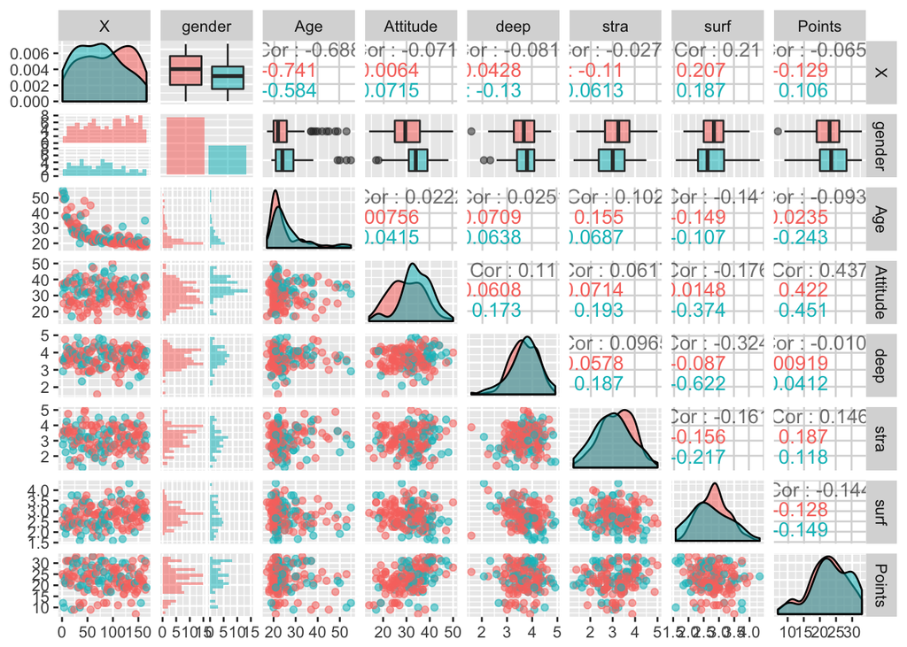

From all the variables analysed, strategic_questions is the one that shows a more normal distributon, all the other data seems slighly to dramatically skewed.

- Based in the previous observations it seems interesting to visualize how the attitute (that seems to vary most with gender) correlates with the acquired Points.

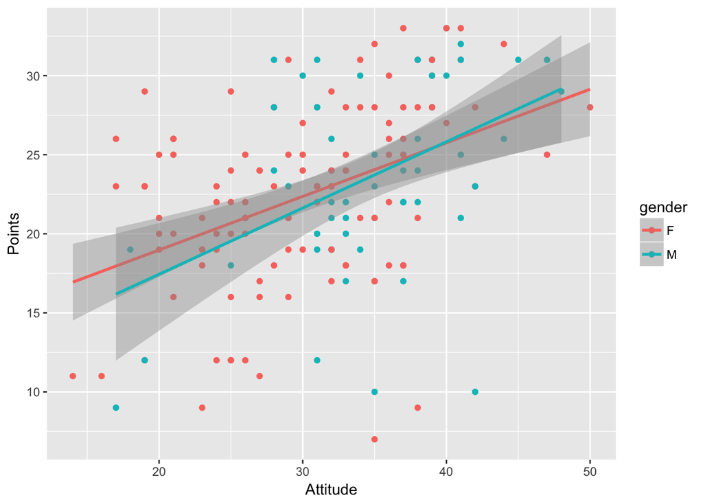

- You can verify in the graph how the correlation trend varies between female (red line) and male (blue line). The grey area in the graph shows you how this data varies.

```r
#Linear model with three explanatory variables
my_model <- lm(formula = Points ~ Attitude + stra + surf, data = learning2014)

#Summary of the linear model
summary(my_model)
```

```
##
## Call:
## lm(formula = Points ~ Attitude + stra + surf, data = learning2014)
##
## Residuals:
##      Min       1Q   Median       3Q      Max
## -17.1550  -3.4346   0.5156   3.6401  10.8952
##
## Coefficients:
##             Estimate Std. Error t value Pr(>|t|)
## (Intercept) 11.01711    3.68375   2.991  0.00322 **
## Attitude     0.33952    0.05741   5.913 1.93e-08 ***
## stra         0.85313    0.54159   1.575  0.11716
## surf        -0.58607    0.80138  -0.731  0.46563
## ---
## Signif. codes:  0 '***' 0.001 '**' 0.01 '*' 0.05 '.' 0.1 ' ' 1
##
## Residual standard error: 5.296 on 162 degrees of freedom
## Multiple R-squared:  0.2074, Adjusted R-squared:  0.1927
## F-statistic: 14.13 on 3 and 162 DF,  p-value: 3.156e-08
```

```r
#Linear model with three explanatory variables
my_model <- lm(formula = Points ~ Attitude, data = learning2014)

#Summary of the linear model
summary(my_model)
```

```
##
## Call:
## lm(formula = Points ~ Attitude, data = learning2014)
##
## Residuals:
##      Min       1Q   Median       3Q      Max
## -16.9763  -3.2119   0.4339   4.1534  10.6645
##
## Coefficients:
##             Estimate Std. Error t value Pr(>|t|)
## (Intercept) 11.63715    1.83035   6.358 1.95e-09 ***
## Attitude     0.35255    0.05674   6.214 4.12e-09 ***
## ---
## Signif. codes:  0 '***' 0.001 '**' 0.01 '*' 0.05 '.' 0.1 ' ' 1
##
## Residual standard error: 5.32 on 164 degrees of freedom
## Multiple R-squared:  0.1906, Adjusted R-squared:  0.1856
## F-statistic: 38.61 on 1 and 164 DF,  p-value: 4.119e-09
```

### 1.2.4 **Normal Q-Q plot**

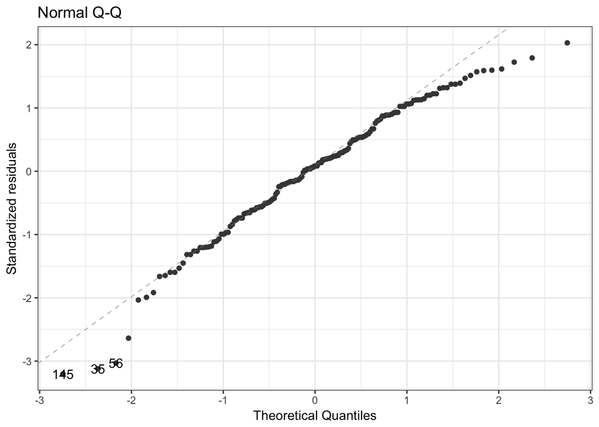

```r
library(ggfortify)
autoplot(my_model, which= 2) +
     theme_bw()
```